# Demographic Clustering

Robin Burke

1/8/2017

This file computes a clustering of the library branches based on principal components.

```r
library(knitr)
setwd("/home/rburke/oboc/src/rcr-analysis/src/demographic")
read_chunk("cluster.R")
```

### Project constants

```r
# Load project constants
setwd("/home/rburke/oboc/src/rcr-analysis/src")
source("common.R")

library(caret)
```

```r
library(stats)
library(gplots)
library(ggplot2)
library(GGally)
library(RColorBrewer)
library(plyr)
library(cluster)
library(reshape2)
```

### Loading the principal components data

```r
# Read the principal components of the demographic data
path.demo <- paste(RCR_DATA, "branch/branch-data-prcomp-",
                   DATA_VERSION, ".csv", sep="")
demo <- read.csv(path.demo)
```

### Drop unused rows and columns

Remove non-demographic columns. Remove regional libraries as their demographics are just aggregations of the others. Create two data frames with 16 and 8 components, respectively.

```r
# Drop the regional libraries and extraneous columns
code.drop <- c("H0", "S1", "W1")

demo.noH0 <- demo[demo$Code!="H0",]
demo.noRG <- demo[!(demo$Code %in% code.drop),]

branchPC16 <- demo.noRG[,c("PC1", "PC2", "PC3", "PC4", "PC5", "PC6", "PC7", "PC8",
                      "PC9", "PC10", "PC11", "PC12", "PC13", "PC14", "PC15", "PC16")]


branchPC8 <- demo.noRG[,c("PC1", "PC2", "PC3", "PC4", "PC5", "PC6", "PC7", "PC8")]
```

## Clustering computation

### A function to try clusterins

Using PAM - Partitioning Around Medoids.

```r
# A function to explore different clustering

try_pam <- function(data,k) {
  set.seed(327)
  branch.pam <- pam(data, k)
  diss <- daisy(data)
  sil <- silhouette(branch.pam$cluster, diss)
  plot(sil)
  return (branch.pam)
}
```

### k=3, 16 components

```r
# k = 3
cl16_3 <- try_pam(branchPC16, 3)
```

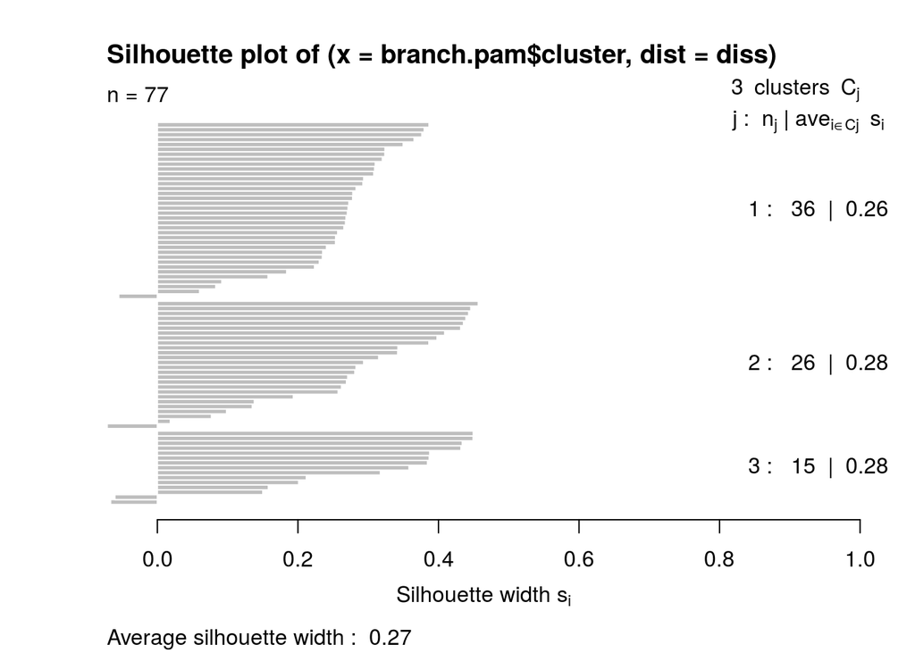

### k=4

```r
# k = 4
cl16_4 <- try_pam(branchPC16, 4)
```

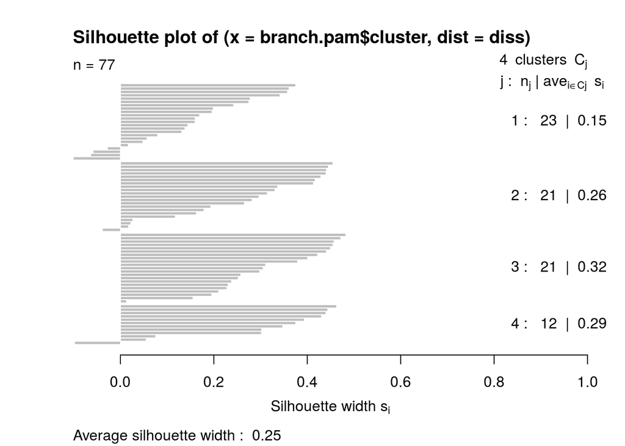

### k=5

```r
# k = 5
cl16_5 <- try_pam(branchPC16, 5)
```

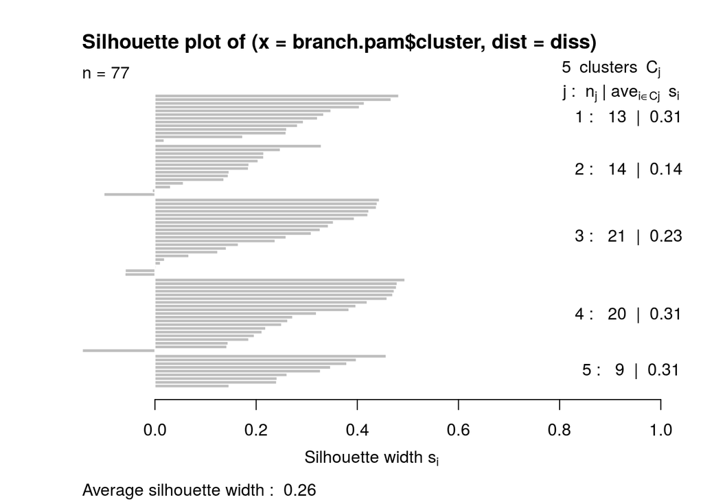

### k=6

```r
# k = 6
cl16_6 <- try_pam(branchPC16, 6)
```

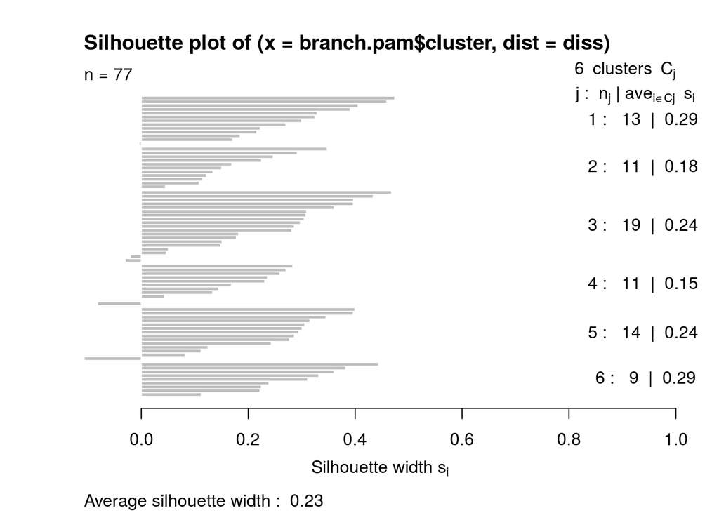

### k=7

```r
# k = 7
cl16_7 <- try_pam(branchPC16, 7)
```

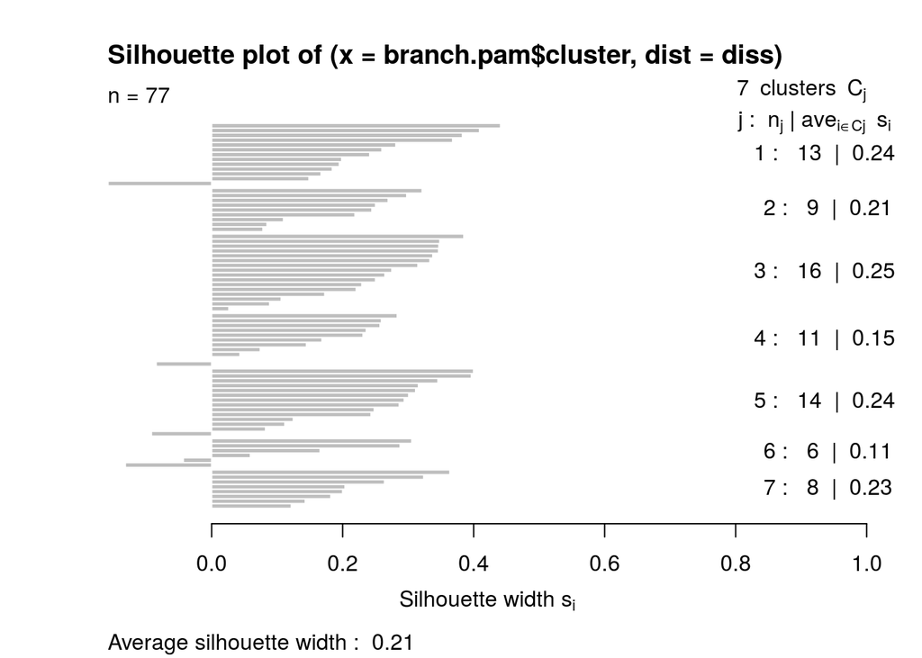

### k=4, 8 components

```r
# k = 4
cl8_4 <- try_pam(branchPC8, 4)
```

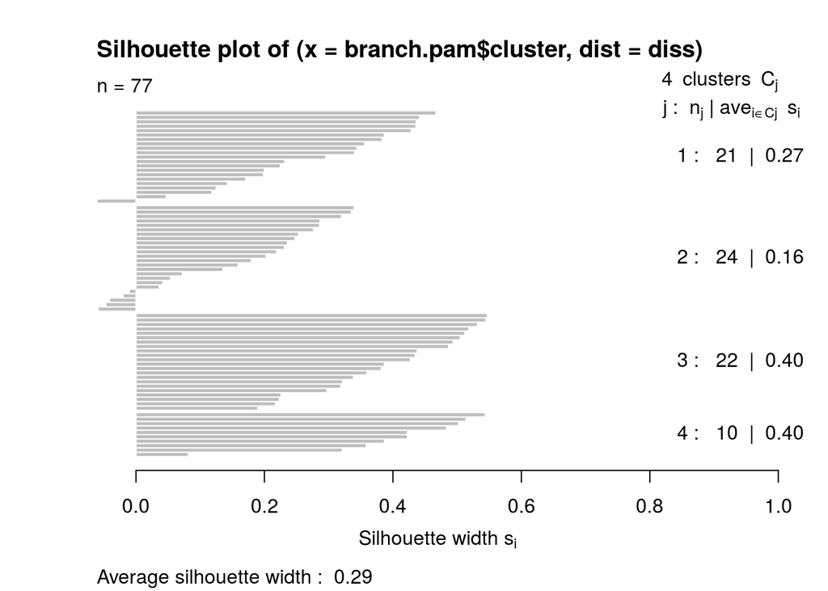

### k=5

```r
# k = 5
cl8_5 <- try_pam(branchPC8, 5)
```

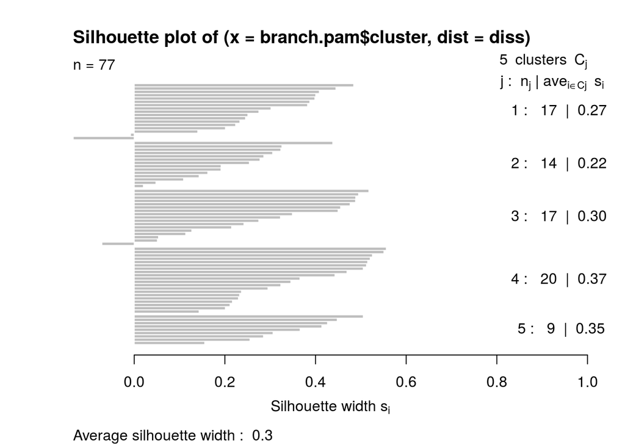

### k=6

```r
# k = 6
cl8_6 <- try_pam(branchPC8, 6)
```

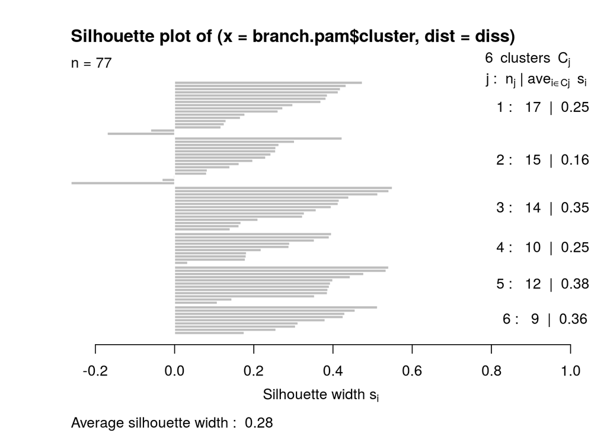

### Choosing k = 5, with PC = 8

Adding back in the regional libraries as cluster 6.

```r
# Slight improvement for PC8, k=5
branch.clust <- data.frame(Code=demo.noRG$Code, Cluster=cl8_5$clustering)
omitted <- data.frame(Code=code.drop, Cluster=6)
full.clust <- rbind(branch.clust, omitted)
```

### Saving

```r
path.clust <- paste(RCR_DATA, "branch/branch-cluster-",
                   DATA_VERSION, ".csv", sep="")
write.csv(branch.clust, file=path.clust, row.names=FALSE)
```

### Examining the medoids

```r
medoids <- cl8_5$medoids

clust.info <- data.frame(Cluster=c("C1", "C2", "C3", "C4", "C5"), PC1=medoids[,1],
                         PC2X=medoids[,2], PC3=medoids[,3], PC4=medoids[,4])

clust.melt <- melt(clust.info, id.vars=c("Cluster"))
colnames(clust.melt) <- c("Cluster", "Component", "Weight")
```

### Plot of component weight in each cluster

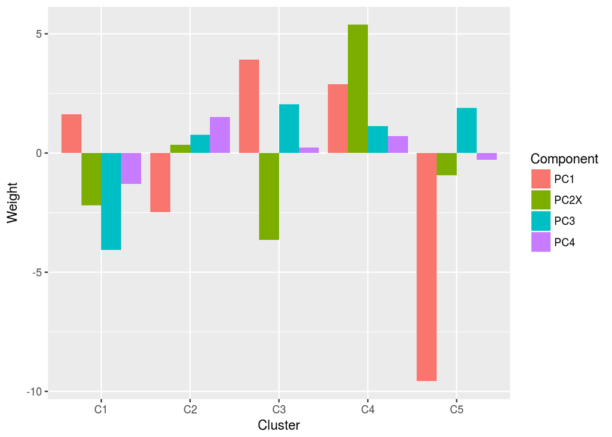

```r
p <- ggplot(data=clust.melt, aes(x=Cluster, y=Weight, fill=Component))
p <- p + geom_bar(stat="identity", position="dodge")
p <- p + scale_fill_discrete()
print (p)
```

Cluster 1 is diverse with more renters, more folks close to work or unemployed.

Cluster 2 is more white with more homeowners, public transit users.

Cluster 3 is poorer and more Latinx residents, but homeowners.

Cluster 4 is similar to cluster 3, but with African-American residents, slightly greater property values, possibly because of rental units.

Cluster 5 is affluent neighborhoods, mostly white residents.

Note also that these are mediods – particular branch areas that are representative of their clusters. A better visualization would be to show the distribution of each component in the clusters. See cluster-viz.Rmd

## Updating database

### Set up

```r
library(RMySQL)
library(getPass)
#password <- getPass("MySQL Password:", noblank=TRUE)
#username <- "rburke"
```

### Connect to database

```r
con <- dbConnect(MySQL(),
                 user=params$username, password=params$password,
                 dbname="oboc", host="localhost")
```

### Write cluster table

```r
dbSendQuery(con, "DROP TABLE IF EXISTS oboc.temp_cluster")
```

```
## <MySQLResult:60054208,0,0>
```

```r
dbWriteTable(con, "temp_cluster", full.clust)
```

```
## [1] TRUE
```

### Update branch table

```r
update_query <- paste("update CPL_branch B, temp_cluster T ",
    "set B.cluster_branch = T.Cluster where B.code_branch = T.Code",
    sep=' ')
dbSendQuery(con, update_query)
```

```
## <MySQLResult:1,0,4>
```

### Clean up

```r
dbSendQuery(con, "DROP TABLE IF EXISTS oboc.temp_cluster")
```

```
## <MySQLResult:160873304,0,5>
```

```r
dbDisconnect(con)
```

```
## [1] TRUE
```